# Modeller

```r
suppressPackageStartupMessages({
  library(tidyverse)
  library(lubridate)
  library(modelr)
  library(broom)
  library(lmtest)
  library(sandwich)
  library(viridis)
})

knitr::opts_chunk$set(echo=TRUE, include = TRUE)
```

```r
pm2 <- read_csv("data/pm2.csv", show_col_types = FALSE)
```

```r
pm2 <- pm2 %>%
  mutate(
    fnr = str_sub(knr, 1,2),
    aar_f = str_sub(aar)
  )
```

```r
head(pm2)
```

| knr | aar | knavn | pm2 | Menn_ya_p | Kvinner_ya_p | Total_ya_p | inc_k1 | inc_k5 | uni_k_mf | uni_k_m | uni_k_f | uni_l_mf | uni_l_m | uni_l_f | Trade_p | fnr | aar_f |
| --- | --- | --- | --- | --- | --- | --- | --- | --- | --- | --- | --- | --- | --- | --- | --- | --- | --- |
| 0101 | 2008 | Halden | 13427 | 59.74892 | 56.79763 | 58.26214 | 24.5 | 13.6 | 17.8 | 15.1 | 20.4 | 3.9 | 5.4 | 2.4 | 56266 | 01 | 2008 |
| 0101 | 2009 | Halden | 13095 | 59.77860 | 57.04693 | 58.40290 | 24.4 | 14.1 | 18.2 | 15.4 | 20.9 | 3.9 | 5.4 | 2.5 | 56366 | 01 | 2009 |
| 0101 | 2010 | Halden | 13832 | 59.64298 | 57.06300 | 58.34376 | 23.9 | 13.7 | 18.6 | 15.6 | 21.6 | 4.1 | 5.5 | 2.7 | 57210 | 01 | 2010 |
| 0101 | 2011 | Halden | 14915 | 59.84630 | 57.22382 | 58.53183 | 24.0 | 14.0 | 19.0 | 15.8 | 22.2 | 4.4 | 5.8 | 3.0 | 58010 | 01 | 2011 |
| 0101 | 2012 | Halden | 15473 | 59.45122 | 57.00467 | 58.22699 | 23.9 | 14.0 | 19.6 | 16.2 | 22.9 | 4.6 | 5.9 | 3.3 | 58787 | 01 | 2012 |
| 0101 | 2013 | Halden | 15461 | 58.97797 | 56.73872 | 57.85475 | 24.1 | 13.4 | 19.9 | 16.4 | 23.3 | 4.6 | 5.8 | 3.4 | 59453 | 01 | 2013 |

```r
pm2 %>%
  mutate(
    fnr = parse_factor(fnr, levels = fnr),
    aar_f = parse_factor(aar_f, levels = aar_f)
  )
```

| knr | aar | knavn | pm2 | Menn_ya_p | Kvinner_ya_p | Total_ya_p | inc_k1 | inc_k5 | uni_k_mf | uni_k_m | uni_k_f | uni_l_mf | uni_l_m | uni_l_f | Trade_p | fnr | aar_f |
| --- | --- | --- | --- | --- | --- | --- | --- | --- | --- | --- | --- | --- | --- | --- | --- | --- | --- |
| 0101 | 2008 | Halden | 13427 | 59.74892 | 56.79763 | 58.26214 | 24.5 | 13.6 | 17.8 | 15.1 | 20.4 | 3.9 | 5.4 | 2.4 | 56266 | 01 | 2008 |
| 0101 | 2009 | Halden | 13095 | 59.77860 | 57.04693 | 58.40290 | 24.4 | 14.1 | 18.2 | 15.4 | 20.9 | 3.9 | 5.4 | 2.5 | 56366 | 01 | 2009 |
| 0101 | 2010 | Halden | 13832 | 59.64298 | 57.06300 | 58.34376 | 23.9 | 13.7 | 18.6 | 15.6 | 21.6 | 4.1 | 5.5 | 2.7 | 57210 | 01 | 2010 |
| 0101 | 2011 | Halden | 14915 | 59.84630 | 57.22382 | 58.53183 | 24.0 | 14.0 | 19.0 | 15.8 | 22.2 | 4.4 | 5.8 | 3.0 | 58010 | 01 | 2011 |
| 0101 | 2012 | Halden | 15473 | 59.45122 | 57.00467 | 58.22699 | 23.9 | 14.0 | 19.6 | 16.2 | 22.9 | 4.6 | 5.9 | 3.3 | 58787 | 01 | 2012 |
| 0101 | 2013 | Halden | 15461 | 58.97797 | 56.73872 | 57.85475 | 24.1 | 13.4 | 19.9 | 16.4 | 23.3 | 4.6 | 5.8 | 3.4 | 59453 | 01 | 2013 |
| 0101 | 2014 | Halden | 17164 | 58.76014 | 56.72937 | 57.74260 | 23.9 | 13.5 | 20.6 | 17.0 | 24.0 | 4.9 | 6.1 | 3.8 | 63033 | 01 | 2014 |
| 0101 | 2015 | Halden | 17427 | 58.71457 | 56.84787 | 57.78159 | 24.0 | 13.7 | 21.0 | 17.2 | 24.8 | 5.2 | 6.4 | 4.1 | 63747 | 01 | 2015 |
| 0101 | 2016 | Halden | 18941 | 58.68940 | 56.64129 | 57.66763 | 24.0 | 13.8 | 21.4 | 17.4 | 25.4 | 5.4 | 6.5 | 4.4 | 65624 | 01 | 2016 |
| 0101 | 2017 | Halden | 20143 | 58.94138 | 56.85186 | 57.90192 | 23.7 | 14.0 | 21.6 | 17.5 | 25.7 | 5.6 | 6.5 | 4.7 | 65919 | 01 | 2017 |

[output cut: 990 more lines]

```r
pm2 <- pm2 %>%
  mutate(
    Trade_pc_100K = Trade_p/100000
  )
```

```r
head(pm2, n = 4)
```

| knr | aar | knavn | pm2 | Menn_ya_p | Kvinner_ya_p | Total_ya_p | inc_k1 | inc_k5 | uni_k_mf | uni_k_m | uni_k_f | uni_l_mf | uni_l_m | uni_l_f | Trade_p | fnr | aar_f | Trade_pc_100K |
| --- | --- | --- | --- | --- | --- | --- | --- | --- | --- | --- | --- | --- | --- | --- | --- | --- | --- | --- |
| 0101 | 2008 | Halden | 13427 | 59.74892 | 56.79763 | 58.26214 | 24.5 | 13.6 | 17.8 | 15.1 | 20.4 | 3.9 | 5.4 | 2.4 | 56266 | 01 | 2008 | 0.56266 |
| 0101 | 2009 | Halden | 13095 | 59.77860 | 57.04693 | 58.40290 | 24.4 | 14.1 | 18.2 | 15.4 | 20.9 | 3.9 | 5.4 | 2.5 | 56366 | 01 | 2009 | 0.56366 |
| 0101 | 2010 | Halden | 13832 | 59.64298 | 57.06300 | 58.34376 | 23.9 | 13.7 | 18.6 | 15.6 | 21.6 | 4.1 | 5.5 | 2.7 | 57210 | 01 | 2010 | 0.57210 |
| 0101 | 2011 | Halden | 14915 | 59.84630 | 57.22382 | 58.53183 | 24.0 | 14.0 | 19.0 | 15.8 | 22.2 | 4.4 | 5.8 | 3.0 | 58010 | 01 | 2011 | 0.58010 |

```r
tibble("knr", "fnr", "aar_f", "Trade_pc_100k")
```

| "knr" | "fnr" | "aar_f" | "Trade_pc_100k" |
| --- | --- | --- | --- |
| knr | fnr | aar_f | Trade_pc_100k |

#Modell

```r
mod1 <- 'pm2 ~ aar_f + Total_ya_p + inc_k1 + inc_k5 + uni_k_mf + uni_l_mf + Trade_pc_100K'
```

```r
lm1 <- lm(mod1, data = pm2, subset = complete.cases(pm2))
```

Vi legger inn residualene fra den linære modellen

```r
pm2 %>%
add_residuals(lm1)
```

| knr | aar | knavn | pm2 | Menn_ya_p | Kvinner_ya_p | Total_ya_p | inc_k1 | inc_k5 | uni_k_mf | uni_k_m | uni_k_f | uni_l_mf | uni_l_m | uni_l_f | Trade_p | fnr | aar_f | Trade_pc_100K | resid |
| --- | --- | --- | --- | --- | --- | --- | --- | --- | --- | --- | --- | --- | --- | --- | --- | --- | --- | --- | --- |
| 0101 | 2008 | Halden | 13427 | 59.74892 | 56.79763 | 58.26214 | 24.5 | 13.6 | 17.8 | 15.1 | 20.4 | 3.9 | 5.4 | 2.4 | 56266 | 01 | 2008 | 0.56266 | 2749.432077 |
| 0101 | 2009 | Halden | 13095 | 59.77860 | 57.04693 | 58.40290 | 24.4 | 14.1 | 18.2 | 15.4 | 20.9 | 3.9 | 5.4 | 2.5 | 56366 | 01 | 2009 | 0.56366 | 2128.357974 |
| 0101 | 2010 | Halden | 13832 | 59.64298 | 57.06300 | 58.34376 | 23.9 | 13.7 | 18.6 | 15.6 | 21.6 | 4.1 | 5.5 | 2.7 | 57210 | 01 | 2010 | 0.57210 | 1769.151591 |
| 0101 | 2011 | Halden | 14915 | 59.84630 | 57.22382 | 58.53183 | 24.0 | 14.0 | 19.0 | 15.8 | 22.2 | 4.4 | 5.8 | 3.0 | 58010 | 01 | 2011 | 0.58010 | 1629.985324 |
| 0101 | 2012 | Halden | 15473 | 59.45122 | 57.00467 | 58.22699 | 23.9 | 14.0 | 19.6 | 16.2 | 22.9 | 4.6 | 5.9 | 3.3 | 58787 | 01 | 2012 | 0.58787 | 1552.352281 |
| 0101 | 2013 | Halden | 15461 | 58.97797 | 56.73872 | 57.85475 | 24.1 | 13.4 | 19.9 | 16.4 | 23.3 | 4.6 | 5.8 | 3.4 | 59453 | 01 | 2013 | 0.59453 | 1339.145831 |
| 0101 | 2014 | Halden | 17164 | 58.76014 | 56.72937 | 57.74260 | 23.9 | 13.5 | 20.6 | 17.0 | 24.0 | 4.9 | 6.1 | 3.8 | 63033 | 01 | 2014 | 0.63033 | 2682.849395 |
| 0101 | 2015 | Halden | 17427 | 58.71457 | 56.84787 | 57.78159 | 24.0 | 13.7 | 21.0 | 17.2 | 24.8 | 5.2 | 6.4 | 4.1 | 63747 | 01 | 2015 | 0.63747 | 1924.496260 |
| 0101 | 2016 | Halden | 18941 | 58.68940 | 56.64129 | 57.66763 | 24.0 | 13.8 | 21.4 | 17.4 | 25.4 | 5.4 | 6.5 | 4.4 | 65624 | 01 | 2016 | 0.65624 | 2510.739252 |
| 0101 | 2017 | Halden | 20143 | 58.94138 | 56.85186 | 57.90192 | 23.7 | 14.0 | 21.6 | 17.5 | 25.7 | 5.6 | 6.5 | 4.7 | 65919 | 01 | 2017 | 0.65919 | 2325.438501 |

[output cut: 990 more lines]

```r
head(pm2, n = 4)
```

| knr | aar | knavn | pm2 | Menn_ya_p | Kvinner_ya_p | Total_ya_p | inc_k1 | inc_k5 | uni_k_mf | uni_k_m | uni_k_f | uni_l_mf | uni_l_m | uni_l_f | Trade_p | fnr | aar_f | Trade_pc_100K |
| --- | --- | --- | --- | --- | --- | --- | --- | --- | --- | --- | --- | --- | --- | --- | --- | --- | --- | --- |
| 0101 | 2008 | Halden | 13427 | 59.74892 | 56.79763 | 58.26214 | 24.5 | 13.6 | 17.8 | 15.1 | 20.4 | 3.9 | 5.4 | 2.4 | 56266 | 01 | 2008 | 0.56266 |
| 0101 | 2009 | Halden | 13095 | 59.77860 | 57.04693 | 58.40290 | 24.4 | 14.1 | 18.2 | 15.4 | 20.9 | 3.9 | 5.4 | 2.5 | 56366 | 01 | 2009 | 0.56366 |
| 0101 | 2010 | Halden | 13832 | 59.64298 | 57.06300 | 58.34376 | 23.9 | 13.7 | 18.6 | 15.6 | 21.6 | 4.1 | 5.5 | 2.7 | 57210 | 01 | 2010 | 0.57210 |
| 0101 | 2011 | Halden | 14915 | 59.84630 | 57.22382 | 58.53183 | 24.0 | 14.0 | 19.0 | 15.8 | 22.2 | 4.4 | 5.8 | 3.0 | 58010 | 01 | 2011 | 0.58010 |

```r
summary(lm1)
```

```
Call:
lm(formula = mod1, data = pm2, subset = complete.cases(pm2))

Residuals:
    Min      1Q  Median      3Q     Max
-8516.6 -1472.1   -29.9  1467.3 15736.3

Coefficients:
               Estimate Std. Error t value Pr(>|t|)
(Intercept)   -20400.74    2663.02  -7.661 2.79e-14 ***
aar_f2009        104.15     244.77   0.426 0.670512
aar_f2010        908.13     245.16   3.704 0.000217 ***
aar_f2011       1663.93     245.86   6.768 1.68e-11 ***
aar_f2012       2240.48     247.10   9.067  < 2e-16 ***
aar_f2013       2869.30     248.31  11.555  < 2e-16 ***
aar_f2014       2863.22     250.54  11.428  < 2e-16 ***
aar_f2015       3525.22     253.08  13.929  < 2e-16 ***
aar_f2016       4274.99     255.81  16.711  < 2e-16 ***
aar_f2017       5146.33     258.50  19.909  < 2e-16 ***
Total_ya_p       582.44      38.94  14.957  < 2e-16 ***
inc_k1          -376.99      30.29 -12.445  < 2e-16 ***
inc_k5           194.35      22.87   8.498  < 2e-16 ***
uni_k_mf         -82.02      29.42  -2.788 0.005357 **
uni_l_mf        1206.86      42.22  28.585  < 2e-16 ***
Trade_pc_100K    871.99     218.42   3.992 6.77e-05 ***
---
Signif. codes:  0 ‘***’ 0.001 ‘**’ 0.01 ‘*’ 0.05 ‘.’ 0.1 ‘ ’ 1

Residual standard error: 2531 on 2124 degrees of freedom
Multiple R-squared:  0.8346,    Adjusted R-squared:  0.8334
F-statistic: 714.3 on 15 and 2124 DF,  p-value: < 2.2e-16
```

Vi antar at de øvrige koeffisientene er som forventet, da kvadrattmeter prisen har til vane å øke fra år til år.

#Heteroskedastisitet

```r
bptest(lm1)
```

```
    studentized Breusch-Pagan test

data:  lm1
BP = 352.89, df = 15, p-value < 2.2e-16
```

Ja vi har problemer med heteroskedasiteten her pga at verdien er for høy.

```r
coeftest(lm1)
```

```
t test of coefficients:

                Estimate Std. Error  t value  Pr(>|t|)
(Intercept)   -20400.742   2663.022  -7.6607 2.790e-14 ***
aar_f2009        104.150    244.767   0.4255 0.6705118
aar_f2010        908.129    245.156   3.7043 0.0002174 ***
aar_f2011       1663.926    245.857   6.7679 1.685e-11 ***
aar_f2012       2240.475    247.095   9.0672 < 2.2e-16 ***
aar_f2013       2869.297    248.315  11.5551 < 2.2e-16 ***
aar_f2014       2863.224    250.537  11.4283 < 2.2e-16 ***
aar_f2015       3525.223    253.083  13.9291 < 2.2e-16 ***
aar_f2016       4274.990    255.812  16.7114 < 2.2e-16 ***
aar_f2017       5146.326    258.498  19.9086 < 2.2e-16 ***
Total_ya_p       582.436     38.941  14.9568 < 2.2e-16 ***
inc_k1          -376.989     30.291 -12.4455 < 2.2e-16 ***
inc_k5           194.354     22.871   8.4979 < 2.2e-16 ***
uni_k_mf         -82.023     29.424  -2.7876 0.0053574 **
uni_l_mf        1206.857     42.219  28.5853 < 2.2e-16 ***
Trade_pc_100K    871.993    218.422   3.9922 6.768e-05 ***
---
Signif. codes:  0 ‘***’ 0.001 ‘**’ 0.01 ‘*’ 0.05 ‘.’ 0.1 ‘ ’ 1
```

```r
vcovHC(lm1)
```

```
              (Intercept)    aar_f2009   aar_f2010   aar_f2011   aar_f2012    aar_f2013    aar_f2014    aar_f2015
(Intercept)    9297989.37 -26519.17426 -34751.3931 -64358.9799 -88195.7750 -93332.21682 -128032.5143 -177893.2733
aar_f2009       -26519.17  42579.51052  22306.6988  22379.0191  22461.1963  22562.49160   22647.2088   22637.7427
aar_f2010       -34751.39  22306.69876  41857.2132  22643.0594  22816.5776  23016.04825   23232.1454   23267.9132
aar_f2011       -64358.98  22379.01911  22643.0594  45210.7304  23406.9880  23690.13111   24076.5421   24237.7165
aar_f2012       -88195.78  22461.19628  22816.5776  23406.9880  47055.4187  24270.53282   24791.9383   25055.0255
aar_f2013       -93332.22  22562.49160  23016.0483  23690.1311  24270.5328  49220.90256   25428.8815   25755.4473
aar_f2014      -128032.51  22647.20878  23232.1454  24076.5421  24791.9383  25428.88146   53475.4422   27156.8674
aar_f2015      -177893.27  22637.74268  23267.9132  24237.7165  25055.0255  25755.44730   27156.8674   63394.1122
aar_f2016      -229170.12  22623.80635  23323.0788  24446.1520  25385.7301  26135.55952   27482.0673   28309.5656
aar_f2017      -231919.09  22624.44448  23352.3686  24515.4258  25408.7607  26169.54649   27045.3309   27655.2812
Total_ya_p     -134378.95     89.41919    277.8154    681.8928   1112.5721   1311.74280    1662.7240    2349.7551
inc_k1          -48847.48    -46.78668   -117.7882    188.8338    193.4766    -23.25608     237.9932     438.1822
inc_k5          -26724.41    110.78484    126.8286    397.1950    455.5137    419.80206     750.9501     927.6337
uni_k_mf        -23624.40   -129.42390   -212.3787   -468.5265   -572.7298   -695.90501    -198.2867     136.4018
uni_l_mf         79213.28    -45.36231   -237.3954   -324.3915   -491.9711   -632.27758   -2195.0185   -3034.7846
Trade_pc_100K   145568.84    497.16540   1261.8579    987.3383    936.1196   2510.69810    2684.4013    2764.2300
                 aar_f2016    aar_f2017    Total_ya_p       inc_k1      inc_k5     uni_k_mf    uni_l_mf Trade_pc_100K
(Intercept)   -229170.1243 -231919.0869 -134378.94615 -48847.47803 -26724.4053 -23624.40438 79213.27980   145568.8365
aar_f2009       22623.8064   22624.4445      89.41919    -46.78668    110.7848   -129.42390   -45.36231      497.1654
aar_f2010       23323.0788   23352.3686     277.81538   -117.78822    126.8286   -212.37867  -237.39541     1261.8579
aar_f2011       24446.1520   24515.4258     681.89276    188.83384    397.1950   -468.52650  -324.39148      987.3383
aar_f2012       25385.7301   25408.7607    1112.57212    193.47663    455.5137   -572.72977  -491.97106      936.1196
aar_f2013       26135.5595   26169.5465    1311.74280    -23.25608    419.8021   -695.90501  -632.27758     2510.6981
aar_f2014       27482.0673   27045.3309    1662.72401    237.99318    750.9501   -198.28673 -2195.01848     2684.4013
aar_f2015       28309.5656   27655.2812    2349.75511    438.18220    927.6337    136.40176 -3034.78456     2764.2300
aar_f2016       75087.4602   28071.1160    3130.99055    706.91052   1166.2786   -110.12216 -2540.74265      282.6406
aar_f2017       28071.1160   89424.5717    3266.65535    723.96826   1178.1709   -816.28793 -1110.77830     1862.4720
Total_ya_p       3130.9906    3266.6554    2167.75020    426.37025    133.2185     51.21924  -614.02732    -1619.3416
inc_k1            706.9105     723.9683     426.37025    801.89764    496.4444    158.26504  -500.25996    -2293.0328
inc_k5           1166.2786    1178.1709     133.21845    496.44438    547.3448    104.53767  -690.28424     -115.1786
uni_k_mf         -110.1222    -816.2879      51.21924    158.26504    104.5377   1515.96690 -2398.54359    -2608.7728
uni_l_mf        -2540.7427   -1110.7783    -614.02732   -500.25996   -690.2842  -2398.54359  5463.68941      651.9410
Trade_pc_100K     282.6406    1862.4720   -1619.34164  -2293.03278   -115.1786  -2608.77275   651.94105    60897.1826
```

#Flytter residualene fra lm1 til datasettet pm2

```r
pm2 <- pm2 %>%
  add_residuals(lm1)
```

lager ny variabel

```r
pm2 <- pm2 %>%
mutate(aar_d = make_date(aar))
```

Vi filterer ut fylkene Østfold, Akershus, Oslo, Rogaland og Hordaland

```r
pm2 <- pm2 %>%
mutate(fylke = substr(knr, start = 1, stop = 2))
```

```r
pm2_red <- pm2 %>%
  filter(fylke %in% c("01", "02", "03", "11", "12"))
```

Oppgave 7 til 10

```r
# pm2_red %>%
#   unnest(c(fylke)) %>%
#   group_by(fylke, aar_d) %>%
#   summarise(mean_fylke = mean(resid)) %>%
#   ggplot(mapping = aes(x = aar_d, y = mean_fylke, colour = fylke)) +
#   geom_line(lwd = 1) +
#   geom_hline(yintercept = 0, colour = "white") +
#   theme(legend.position = "bottom")
```

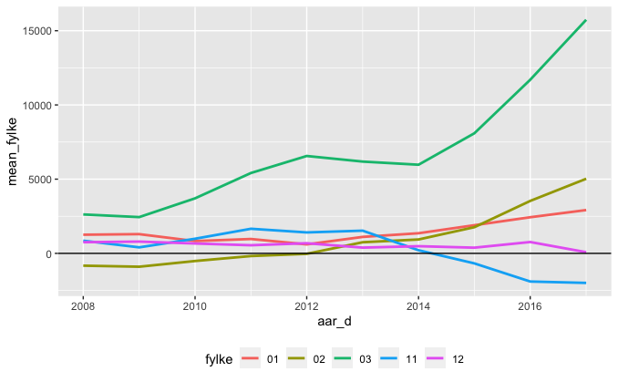

```r
pm2_red %>%
  filter(fylke %in% c("01", "02", "03", "11", "12")) %>%
  unnest(c(fylke)) %>%
  group_by (fylke, aar_d) %>%
  summarise(mean_fylke = mean(resid)) %>%
  ggplot(aes(x=aar_d, y=mean_fylke, colour = fylke)) +
  geom_line(lwd=1) +
  geom_hline(yintercept = 0, colour = "black") +
  theme(legend.position = "bottom")
```

#Dummy fylke og år

Vi innfører en dummy for hvert fylke

```r
# Nå har vi hel pm2 å bruke
mod2 <- 'pm2 ~ fnr*aar_f + Total_ya_p + inc_k1 + inc_k5 + uni_k_mf + uni_l_mf + Trade_pc_100K'
```

Vi genererer lm 2 fra modell 2 og datasettet pm2

```r
lm2 <- lm(mod2, data = pm2)
```

```r
summary(lm2)
```

```
Call:
lm(formula = mod2, data = pm2)

Residuals:
   Min     1Q Median     3Q    Max
 -8546  -1191     32   1198   8328

Coefficients:
                  Estimate Std. Error t value Pr(>|t|)
(Intercept)     -21200.688   2521.645  -8.407  < 2e-16 ***
fnr02            -1482.789    702.970  -2.109 0.035045 *
fnr03             3248.234   2190.443   1.483 0.138260
fnr04            -1049.219    774.264  -1.355 0.175537
fnr05            -1937.388    758.293  -2.555 0.010696 *
fnr06            -2172.731    772.094  -2.814 0.004941 **
fnr07             -737.995   1080.348  -0.683 0.494620
fnr08            -3213.279    878.620  -3.657 0.000262 ***
fnr09            -1219.813    913.691  -1.335 0.182020
fnr10             -281.375    852.265  -0.330 0.741323
fnr11             -565.360    771.927  -0.732 0.464012
fnr12             -903.071    742.464  -1.216 0.224012
fnr14            -3339.829   1182.013  -2.826 0.004768 **
fnr15            -3619.198    715.832  -5.056 4.69e-07 ***
fnr16            -1093.217    759.677  -1.439 0.150296
fnr17            -2005.965    917.216  -2.187 0.028860 *
fnr18            -1567.503    774.530  -2.024 0.043126 *
fnr19            -2856.881   1326.142  -2.154 0.031341 *
fnr20            -2656.315   1180.088  -2.251 0.024500 *
aar_f2009           94.009    744.240   0.126 0.899496
aar_f2010          417.129    744.379   0.560 0.575290
aar_f2011         1280.914    744.731   1.720 0.085597 .
aar_f2012         1455.525    745.679   1.952 0.051088 .
aar_f2013         2479.533    746.367   3.322 0.000910 ***
aar_f2014         2795.831    747.254   3.741 0.000188 ***
aar_f2015         3987.973    748.109   5.331 1.09e-07 ***
aar_f2016         5264.965    749.169   7.028 2.89e-12 ***
aar_f2017         6618.572    749.430   8.831  < 2e-16 ***
Total_ya_p         511.787     36.100  14.177  < 2e-16 ***
inc_k1            -243.050     27.007  -9.000  < 2e-16 ***
inc_k5             251.645     22.916  10.981  < 2e-16 ***
```

[output cut: 156 more lines]

```
fnr11:aar_f2017  -3863.610   1073.185  -3.600 0.000326 ***
fnr12:aar_f2017  -2046.447   1038.104  -1.971 0.048828 *
fnr14:aar_f2017  -2074.192   1665.271  -1.246 0.213077
fnr15:aar_f2017  -2799.827    999.681  -2.801 0.005149 **
fnr16:aar_f2017  -2278.453   1070.923  -2.128 0.033499 *
fnr17:aar_f2017  -2761.733   1290.527  -2.140 0.032479 *
fnr18:aar_f2017  -2661.041   1090.689  -2.440 0.014785 *
fnr19:aar_f2017   -716.410   1873.886  -0.382 0.702272
fnr20:aar_f2017  -3922.387   1665.464  -2.355 0.018615 *
---
Signif. codes:  0 ‘***’ 0.001 ‘**’ 0.01 ‘*’ 0.05 ‘.’ 0.1 ‘ ’ 1

Residual standard error: 2105 on 1944 degrees of freedom
Multiple R-squared:  0.8953,    Adjusted R-squared:  0.8848
F-statistic: 85.21 on 195 and 1944 DF,  p-value: < 2.2e-16
```

Vi legger inn residualene fra lm2 til pm2 og kaller dem res_m2

```r
pm2 <- pm2 %>%
  mutate(res_m2 = resid(lm2))
```

Vi filtrer fylkene

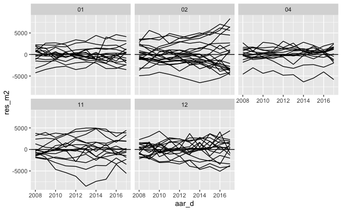

```r
pm2 %>% filter(fnr %in% c("01", "02", "04", "11", "12")) %>%
ggplot(mapping = aes(x = aar_d, y = res_m2)) +
geom_line(aes(group = knavn)) +
scale_size_manual(values = c(seq(2.0, 0.5, by = -0.1))) +
geom_hline(yintercept = 0) +
theme(legend.position = 'bottom') +
  facet_wrap(~fylke)
```

Ut fra modell 2 kan de være vanskelig å eksakte svar. med flere variabler ville nok bilde blitt et annet.

#Vi filtrerer med hensyn på fylke “11”

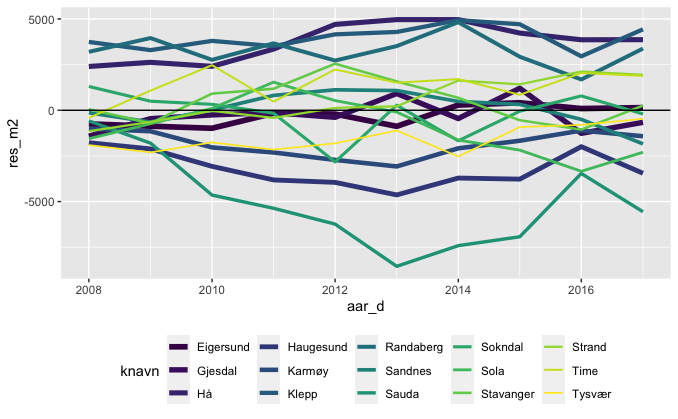

```r
pm2 %>% filter(fnr %in% c("11")) %>%
ggplot(mapping = aes(x = aar_d, y = res_m2)) +
scale_color_viridis(discrete = TRUE, option = "D") +
geom_line(aes(group = knavn, colour = knavn, size = knavn)) +
scale_size_manual(values = c(seq(2.0, 0.5, by = -0.1))) +
geom_hline(yintercept = 0) +
theme(legend.position = 'bottom')
```

#Vi gjentar plottet ovenfor med utvalgte kommuner

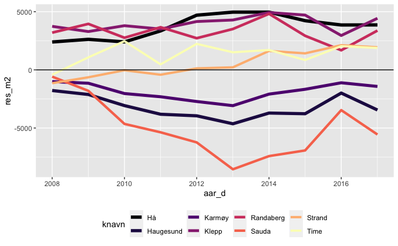

```r
pm2 %>% filter(knr %in% c("1119", "1120", "1127", "1121", "1130", "1135", "1106", "1149")) %>%
ggplot(mapping = aes(x = aar_d, y = res_m2)) +
scale_color_viridis(discrete = TRUE, option = "A") +
geom_line(aes(group = knavn, colour = knavn, size =knavn)) +
scale_size_manual(values = c(seq(2.0, 0.5, by = -0.1))) +
geom_hline(yintercept = 0) +
theme(legend.position = 'bottom')
```

Det som kjennetegner de utvalgte kommunene i Rogaland stor spredning fra kommunene. vi kan se at Sauda blir undervurdert i forhold til gjennomsnittet mens Hå og Klepp blir overvurdert. som vil si de har dyrere kvadratmeter pris i forhold til gjennomsnittet.

#Modell for hvert år

```r
pm2_n <- pm2 %>%
# velger først variablene. Tar med aar_d
   select(pm2, fnr, knr, aar, aar_f, aar_d, Menn_ya_p,
          Kvinner_ya_p, Total_ya_p, inc_k1, inc_k5, uni_k_mf,
          uni_l_mf, Trade_pc_100K) %>%
  # grupperer mht. aar_d som er date object
  group_by(aar_d) %>%
  nest()
```

```r
pm2_n
```

| aar_d | data |
| --- | --- |
| 2008-01-01 |  |
| 2009-01-01 |  |
| 2010-01-01 |  |
| 2011-01-01 |  |
| 2012-01-01 |  |
| 2013-01-01 |  |
| 2014-01-01 |  |
| 2015-01-01 |  |
| 2016-01-01 |  |
| 2017-01-01 |  |

```r
# Ser bra ut ;-)
pm2_n$data[[1]] %>%
 head(n = 5)
```

| pm2 | fnr | knr | aar | aar_f | Menn_ya_p | Kvinner_ya_p | Total_ya_p | inc_k1 | inc_k5 | uni_k_mf | uni_l_mf | Trade_pc_100K |
| --- | --- | --- | --- | --- | --- | --- | --- | --- | --- | --- | --- | --- |
| 13427 | 01 | 0101 | 2008 | 2008 | 59.74892 | 56.79763 | 58.26214 | 24.5 | 13.6 | 17.8 | 3.9 | 0.56266 |
| 18299 | 01 | 0104 | 2008 | 2008 | 60.69851 | 58.67423 | 59.66705 | 22.8 | 16.2 | 19.1 | 5.5 | 0.69916 |
| 14981 | 01 | 0105 | 2008 | 2008 | 60.89855 | 58.06389 | 59.47153 | 22.2 | 13.6 | 16.3 | 2.8 | 0.63674 |
| 15671 | 01 | 0106 | 2008 | 2008 | 59.81091 | 57.82070 | 58.79460 | 21.8 | 16.2 | 19.0 | 4.3 | 0.69040 |
| 18844 | 01 | 0111 | 2008 | 2008 | 61.67247 | 61.27049 | 61.47438 | 17.8 | 19.0 | 18.3 | 4.7 | 0.75027 |

```r
dim(pm2_n)
```

```
[1] 10  2
```

```r
# må bruke a_df i funksjonen ellers vil den alltid bruke pm2
kom_model <- function(a_df) {
   lm(pm2 ~ fnr + Total_ya_p + inc_k1 + inc_k5 + uni_k_mf + uni_l_mf + Trade_pc_100K, data = a_df)
}
```

```r
pm2_n <- pm2_n %>%
   mutate(model = map(data, .f = kom_model))
```

```r
# kom_model(pm2_n$aar) %>%
# summary()
```

```r
mod_sum <- pm2_n %>%
   mutate(mod_summary = map(.x = model, .f = glance)) %>%
   unnest(mod_summary) %>%
   print()
```

| aar_d | data | model | r.squared | adj.r.squared | sigma | statistic | p.value | df | logLik | AIC | BIC | deviance | df.residual | nobs |
| --- | --- | --- | --- | --- | --- | --- | --- | --- | --- | --- | --- | --- | --- | --- |
| 2008-01-01 |  |  | 0.8730387 | 0.8569167 | 1700.826 | 54.15179 | 1.191043e-71 | 24 | -1882.278 | 3816.557 | 3904.072 | 546740767 | 189 | 214 |
| 2009-01-01 |  |  | 0.8859321 | 0.8714473 | 1614.401 | 61.16281 | 5.625260e-76 | 24 | -1871.118 | 3794.237 | 3881.752 | 492589131 | 189 | 214 |
| 2010-01-01 |  |  | 0.8878764 | 0.8736385 | 1743.338 | 62.35999 | 1.134757e-76 | 24 | -1887.562 | 3827.123 | 3914.638 | 574414039 | 189 | 214 |
| 2011-01-01 |  |  | 0.8828933 | 0.8680226 | 1925.339 | 59.37135 | 6.500632e-75 | 24 | -1908.812 | 3869.624 | 3957.139 | 700609809 | 189 | 214 |
| 2012-01-01 |  |  | 0.8906982 | 0.8768186 | 1952.669 | 64.17321 | 1.056334e-77 | 24 | -1911.828 | 3875.656 | 3963.172 | 720641154 | 189 | 214 |
| 2013-01-01 |  |  | 0.8947857 | 0.8814251 | 2025.651 | 66.97222 | 3.028356e-79 | 24 | -1919.681 | 3891.361 | 3978.877 | 775516525 | 189 | 214 |
| 2014-01-01 |  |  | 0.8841952 | 0.8694898 | 2148.974 | 60.12734 | 2.296683e-75 | 24 | -1932.328 | 3916.656 | 4004.171 | 872818946 | 189 | 214 |
| 2015-01-01 |  |  | 0.8788152 | 0.8634266 | 2361.372 | 57.10838 | 1.570283e-73 | 24 | -1952.498 | 3956.996 | 4044.511 | 1053878988 | 189 | 214 |
| 2016-01-01 |  |  | 0.8834452 | 0.8686446 | 2467.480 | 59.68978 | 4.188150e-75 | 24 | -1961.904 | 3975.808 | 4063.324 | 1150718605 | 189 | 214 |
| 2017-01-01 |  |  | 0.8948563 | 0.8815047 | 2613.670 | 67.02250 | 2.844561e-79 | 24 | -1974.222 | 4000.443 | 4087.959 | 1291109834 | 189 | 214 |

```r
coef_df <- mod_sum$model %>%
  # 1 plukker ut koeffisientene
   map_df(1) %>%
  # legges i en tibble
   tibble()
```

```r
# Lager en års variabel i coef_df
coef_df <- coef_df %>%
  mutate(
    aar = ymd(paste(2008:2017, "-01-01", sep = ""))
  ) %>%
  select(aar, everything())
```

```r
# Gjør variabelnavn om til en variabel kalt "variables"
# Verdien på koeffisientene for de ulike variablene i ulike år
# legges i variabelen coef
coef_df_long <- coef_df %>%
   pivot_longer(
     # Tar IKKE med aar
     cols = `(Intercept)`:`Trade_pc_100K`,
     names_to = "variables",
     values_to = "coef")
```

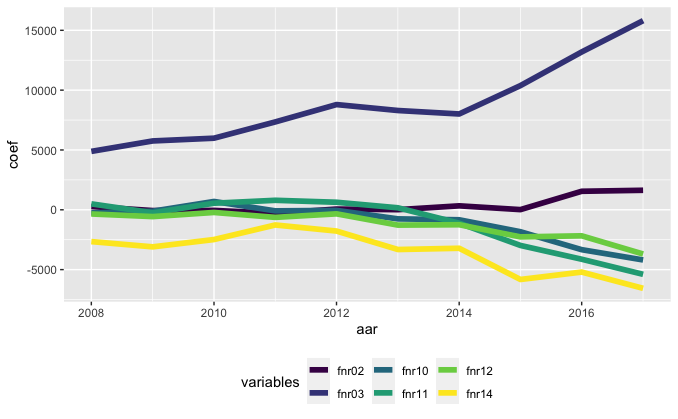

```r
coef_df_long %>%
  # Plukker ut de relevante fylkene
  filter(
    variables %in% c("fnr02", "fnr03", "fnr10", "fnr11", "fnr12", "fnr14")) %>%
 ggplot(mapping = aes(x = aar, y = coef, colour = variables)) +
 scale_color_viridis(discrete = TRUE, option = "D") +
  geom_line(aes(group = variables), lwd = 2) +
  theme(legend.position = 'bottom')
```

I 2014 hadde vi et kraftig fall i råolje-prisen. Det ser ut til å ha gitt et fall i prisen per kvadratmeter på Sør og Vestlandet, mens effekten har vært motsatt for Akershus og særlig Oslo. I modellen er det justert for effekten av befolkning i yrkesaktiv alder, andel av husholdninger i laveste inntekts-kvintil, andel av husholdninger i høyeste inntekts-kvintil, andel av befolkning med kort universitets/høgskole-utdanning, andel av befolkning med lang universitets/høgskole-utdanning og omsetning i detaljhandelen per innbygger. Med unntak av variabelen “Trade_pc_100K” ser koeffisientene til disse variablene ut til å være rimelig stabile over tid.

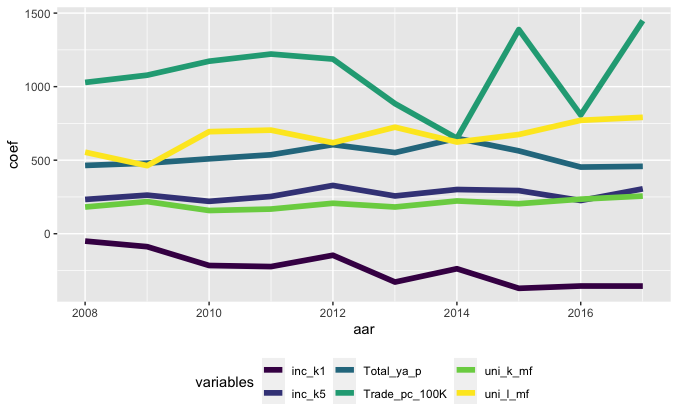

```r
coef_df_long %>%
  select(aar, variables, coef) %>%
  # rettet vaiabelnavnene til inc_k1 og inc_k2
  filter(
    variables %in% c("Total_ya_p", "inc_k1", "inc_k5", "uni_k_mf", "uni_l_mf", "Trade_pc_100K")) %>%
  ggplot(mapping = aes(x = aar, y = coef, colour = variables)) +
  scale_color_viridis(discrete = TRUE, option = "D") +
  geom_line(aes(group = variables), lwd = 2) +
  theme(legend.position = 'bottom')
```

Alle er stabile med unntak av Trade_pc_100K.